# SimpleAnalysis_RPXErosion

Omprakash Samudrala

April 24, 2018

## Simple Analysis

A Naive model - mean of response variable across the data set, did not provide a prediction that passes the success metric.

A simple analysis is attempted, where the response prediction is obtained by two methods

- Multiple Linear Regression
- Regression Tree

Again, for each of the models above, the mean absolute deviation of the response prediction from the actual response is computed.

Figure out if the success metric is achieved (mean absolute deviation < 0.05)

```
## 'data.frame':    9514 obs. of  6 variables:
##  $ MeanProcFlow    : num  210 262 175 175 175 ...
##  $ StDevProcFlow   : num  8.96 11.32 7.12 7.12 5.72 ...
##  $ MeanMotFlow     : num  252 315 210 210 210 252 252 420 252 210 ...
##  $ StDevMotFlow    : num  7.86 18.46 19.26 12.28 3.61 ...
##  $ numRPX          : num  10 8 12 12 12 10 10 6 10 12 ...
##  $ ErosionPotential: num  0.4 0.25 0.417 0.167 0.417 ...
```

```
##   MeanProcFlow   StDevProcFlow     MeanMotFlow   StDevMotFlow
##  Min.   :175.0   Min.   : 4.460   Min.   :210   Min.   : 3.611
##  1st Qu.:175.0   1st Qu.: 7.125   1st Qu.:210   1st Qu.: 4.678
##  Median :210.0   Median : 8.137   Median :252   Median : 8.810
##  Mean   :233.3   Mean   : 9.204   Mean   :280   Mean   :11.002
##  3rd Qu.:262.5   3rd Qu.:10.592   3rd Qu.:315   3rd Qu.:14.939
##  Max.   :350.0   Max.   :20.285   Max.   :420   Max.   :89.885
##      numRPX       ErosionPotential
##  Min.   : 6.000   Min.   :0.0000
##  1st Qu.: 8.000   1st Qu.:0.2500
##  Median :10.000   Median :0.3000
##  Mean   : 9.557   Mean   :0.3050
##  3rd Qu.:12.000   3rd Qu.:0.3750
##  Max.   :12.000   Max.   :0.6667
```

```
##
## Call:
## lm(formula = ErosionPotential ~ MeanProcFlow + StDevProcFlow +
##     StDevMotFlow + numRPX, data = TrgData)
##
## Residuals:
##       Min        1Q    Median        3Q       Max
## -0.258859 -0.063767  0.003337  0.057429  0.309359
##
## Coefficients:
##                 Estimate Std. Error t value Pr(>|t|)
## (Intercept)    0.4208574  0.0488205   8.621  < 2e-16 ***
## MeanProcFlow  -0.0009790  0.0001039  -9.420  < 2e-16 ***
## StDevProcFlow  0.0163171  0.0008220  19.851  < 2e-16 ***
## StDevMotFlow   0.0007075  0.0001591   4.448 8.83e-06 ***
## numRPX        -0.0046652  0.0027576  -1.692   0.0907 .
## ---
## Signif. codes:  0 '***' 0.001 '**' 0.01 '*' 0.05 '.' 0.1 ' ' 1
##
## Residual standard error: 0.0888 on 5703 degrees of freedom
## Multiple R-squared:  0.08522,    Adjusted R-squared:  0.08458
## F-statistic: 132.8 on 4 and 5703 DF,  p-value: < 2.2e-16
```

```
## [1] 0.07037936
```

The summary of the linear model is shown above. The mean absolute deviation of the response prediction was found to be **0.0703794**.

This is more than the success metric requirement of **< 0.05**.

```
##
## Regression tree:
## rpart(formula = ErosionPotential ~ MeanProcFlow + StDevProcFlow +
##     MeanMotFlow + StDevMotFlow + numRPX, data = TrgData, method = "anova")
##
## Variables actually used in tree construction:
## [1] MeanProcFlow  StDevMotFlow  StDevProcFlow
##
## Root node error: 49.162/5708 = 0.0086128
##
## n= 5708
##
##         CP nsplit rel error  xerror     xstd
## 1 0.038081      0   1.00000 1.00027 0.018636
## 2 0.022374      1   0.96192 0.96382 0.017896
## 3 0.017736      4   0.89480 0.89919 0.016282
## 4 0.017672      5   0.87706 0.88406 0.016107
## 5 0.016442      6   0.85939 0.87790 0.016039
## 6 0.010572      7   0.84295 0.85324 0.015662
## 7 0.010000      8   0.83237 0.84530 0.015484
```

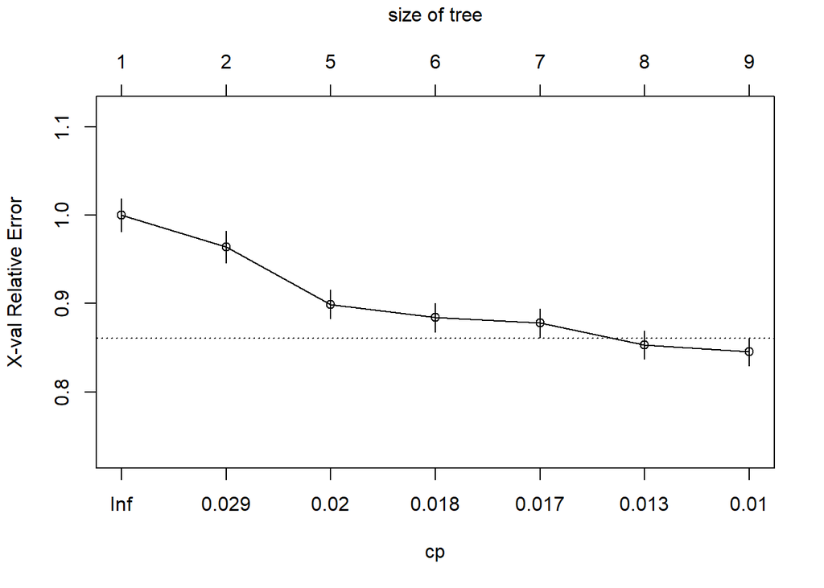

```
## Call:
## rpart(formula = ErosionPotential ~ MeanProcFlow + StDevProcFlow +
##     MeanMotFlow + StDevMotFlow + numRPX, data = TrgData, method = "anova")
##   n= 5708
##
##           CP nsplit rel error    xerror       xstd
## 1 0.03808111      0 1.0000000 1.0002658 0.01863576
## 2 0.02237426      1 0.9619189 0.9638250 0.01789622
## 3 0.01773617      4 0.8947961 0.8991946 0.01628155
## 4 0.01767178      5 0.8770599 0.8840613 0.01610737
## 5 0.01644210      6 0.8593882 0.8778982 0.01603860
## 6 0.01057154      7 0.8429461 0.8532378 0.01566217
## 7 0.01000000      8 0.8323745 0.8453011 0.01548427
##
## Variable importance
## StDevProcFlow  StDevMotFlow   MeanMotFlow  MeanProcFlow        numRPX
##            36            28            12            12            12
##
## Node number 1: 5708 observations,    complexity param=0.03808111
##   mean=0.3063818, MSE=0.008612771
##   left son=2 (2247 obs) right son=3 (3461 obs)
##   Primary splits:
##       StDevMotFlow  < 6.865205 to the left,  improve=0.03808111, (0 missing)
##       StDevProcFlow < 6.96508  to the left,  improve=0.02585025, (0 missing)
##       MeanProcFlow  < 325      to the right, improve=0.01023334, (0 missing)
##       MeanMotFlow   < 390      to the right, improve=0.01023334, (0 missing)
##       numRPX        < 6.5      to the left,  improve=0.01023334, (0 missing)
##   Surrogate splits:
##       StDevProcFlow < 6.966997 to the left,  agree=0.695, adj=0.224, (0 split)
##
## Node number 2: 2247 observations,    complexity param=0.01773617
##   mean=0.2839055, MSE=0.007661661
##   left son=4 (648 obs) right son=5 (1599 obs)
##   Primary splits:
##       StDevMotFlow  < 4.737167 to the right, improve=0.05064782, (0 missing)
##       numRPX        < 9        to the left,  improve=0.03204177, (0 missing)
##       MeanProcFlow  < 236.25   to the right, improve=0.03204177, (0 missing)
##       MeanMotFlow   < 283.5    to the right, improve=0.03204177, (0 missing)
##       StDevProcFlow < 6.733105 to the left,  improve=0.02512054, (0 missing)
##   Surrogate splits:
```

[output cut: 85 more lines]

```
##       MeanMotFlow   < 283.5    to the left,  improve=0.002170533, (0 missing)
##   Surrogate splits:
##       StDevProcFlow < 10.56876 to the right, agree=0.693, adj=0.125, (0 split)
##
## Node number 56: 130 observations
##   mean=0.2205128, MSE=0.009493754
##
## Node number 57: 280 observations
##   mean=0.2970238, MSE=0.007114158
##
## Node number 58: 963 observations
##   mean=0.3041726, MSE=0.007316584
##
## Node number 59: 1787 observations
##   mean=0.3414327, MSE=0.007077933
```

The summary of the regression tree model is shown above. The mean absolute deviation of the response prediction was found to be **0.0694112**.

This is more than the success metric requirement of **< 0.05**.

Both the simple multiple linear regression model and simple regression tree fail to provide response prediction that meet the success metric. Few things to be checked and tried out are

- Are the predictors highly correlated? Try eliminating the predictors or use ridge regression
- Try random forest methods to improve upon the prediction of the regression tree model. I suspect it may not give better results as the tree wasn’t pruned and should not have been very rigid.
- Is the data set adequate? I suspect that more data is needed, especially at different motive and process flows.
- The number of predictors was reduced by just taking just the mean and standard deviation of all RPX motive and process flows as predictors. May be the individual RPX flows need to be brought back in as predictors! Adds 20 more input variables!